# ENV 790.30 - Time Series Analysis for Energy Data | Spring 2023

Assignment 2 - Due date 02/03/23

Wendy Wen

## Submission Instructions

You should open the .rmd file corresponding to this assignment on RStudio. The file is available on our class repository on Github.

Once you have the file open on your local machine the first thing you will do is rename the file such that it includes your first and last name (e.g., “LuanaLima_TSA_A02_Sp23.Rmd”). Then change “Student Name” on line 4 with your name.

Then you will start working through the assignment by **creating code and output** that answer each question. Be sure to use this assignment document. Your report should contain the answer to each question and any plots/tables you obtained (when applicable).

When you have completed the assignment, **Knit** the text and code into a single PDF file. Submit this pdf using Sakai.

## R packages

R packages needed for this assignment:“forecast”,“tseries”, and “dplyr”. Install these packages, if you haven’t done yet. Do not forget to load them before running your script, since they are NOT default packages.\

```r
#Load/install required package here
library(lubridate)
```

```r
library(ggplot2)
library(forecast)
library(Kendall)
library(tseries)
library(tidyverse)
library(readxl)
```

## Data set information

Consider the data provided in the spreadsheet “Table_10.1_Renewable_Energy_Production_and_Consumption_by_Source.xlsx” on our **Data** folder. The data comes from the US Energy Information and Administration and corresponds to the December 2022 Monthly Energy Review. The spreadsheet is ready to be used. You will also find a $.csv$ version of the data “Table_10.1_Renewable_Energy_Production_and_Consumption_by_Source-Edit.csv”. You may use the function $read.table()$ to import the $.csv$ data in R. Or refer to the file “M2_ImportingData_CSV_XLSX.Rmd” in our Lessons folder for functions that are better suited for importing the $.xlsx$.

```r
#Importing data set
energy_data <- read_excel(path="/Users/wendywen/Desktop/ENV790/wendywen_TSA/Data/Table_10.1_Renewable_Energy_Production_and_Consumption_by_Source.xlsx",skip = 12, sheet="Monthly Data",col_names=FALSE)
#Now let's extract the column names from row 11
read_col_names <- read_excel(path="/Users/wendywen/Desktop/ENV790/wendywen_TSA/Data/Table_10.1_Renewable_Energy_Production_and_Consumption_by_Source.xlsx",skip = 10,n_max = 1, sheet="Monthly Data",col_names=FALSE)
colnames(energy_data) <- read_col_names
head(energy_data)
```

| Month | Wood Energy Production | Biofuels Production | Total Biomass Energy Production | Total Renewable Energy Production | Hydroelectric Power Consumption | Geothermal Energy Consumption | Solar Energy Consumption | Wind Energy Consumption | Wood Energy Consumption | Waste Energy Consumption | Biofuels Consumption | Total Biomass Energy Consumption | Total Renewable Energy Consumption |
| --- | --- | --- | --- | --- | --- | --- | --- | --- | --- | --- | --- | --- | --- |
| 1973-01-01 | 129.630 | Not Available | 129.787 | 403.981 | 272.703 | 1.491 | Not Available | Not Available | 129.630 | 0.157 | Not Available | 129.787 | 403.981 |
| 1973-02-01 | 117.194 | Not Available | 117.338 | 360.900 | 242.199 | 1.363 | Not Available | Not Available | 117.194 | 0.144 | Not Available | 117.338 | 360.900 |
| 1973-03-01 | 129.763 | Not Available | 129.938 | 400.161 | 268.810 | 1.412 | Not Available | Not Available | 129.763 | 0.176 | Not Available | 129.938 | 400.161 |
| 1973-04-01 | 125.462 | Not Available | 125.636 | 380.470 | 253.185 | 1.649 | Not Available | Not Available | 125.462 | 0.174 | Not Available | 125.636 | 380.470 |
| 1973-05-01 | 129.624 | Not Available | 129.834 | 392.141 | 260.770 | 1.537 | Not Available | Not Available | 129.624 | 0.210 | Not Available | 129.834 | 392.141 |
| 1973-06-01 | 125.435 | Not Available | 125.611 | 377.232 | 249.859 | 1.763 | Not Available | Not Available | 125.435 | 0.176 | Not Available | 125.611 | 377.232 |

## Question 1

You will work only with the following columns: Total Biomass Energy Production, Total Renewable Energy Production, Hydroelectric Power Consumption. Create a data frame structure with these three time series only. Use the command head() to verify your data.

```r
newdata <- energy_data[,c("Total Biomass Energy Production", "Total Renewable Energy Production", "Hydroelectric Power Consumption")]
head(newdata)
```

| Total Biomass Energy Production | Total Renewable Energy Production | Hydroelectric Power Consumption |
| --- | --- | --- |
| 129.787 | 403.981 | 272.703 |
| 117.338 | 360.900 | 242.199 |
| 129.938 | 400.161 | 268.810 |
| 125.636 | 380.470 | 253.185 |
| 129.834 | 392.141 | 260.770 |
| 125.611 | 377.232 | 249.859 |

## Question 2

Transform your data frame in a time series object and specify the starting point and frequency of the time series using the function ts().

```r
ts_data <- ts(newdata, start = c(1973,1), end = c(2022,9), frequency=12)
head(ts_data)
```

```
##          Total Biomass Energy Production Total Renewable Energy Production
## Jan 1973                         129.787                           403.981
## Feb 1973                         117.338                           360.900
## Mar 1973                         129.938                           400.161
## Apr 1973                         125.636                           380.470
## May 1973                         129.834                           392.141
## Jun 1973                         125.611                           377.232
##          Hydroelectric Power Consumption
## Jan 1973                         272.703
## Feb 1973                         242.199
## Mar 1973                         268.810
## Apr 1973                         253.185
## May 1973                         260.770
## Jun 1973                         249.859
```

## Question 3

Compute mean and standard deviation for these three series.

```r
# Mean
colMeans(ts_data)
```

```
##   Total Biomass Energy Production Total Renewable Energy Production
##                          277.2525                          592.1583
##   Hydroelectric Power Consumption
##                          235.1146
```

```r
# Standard deviation
apply(ts_data,2,sd)
```

```
##   Total Biomass Energy Production Total Renewable Energy Production
##                          91.75367                         191.79783
##   Hydroelectric Power Consumption
##                          44.16116
```

## Question 4

Display and interpret the time series plot for each of these variables. Try to make your plot as informative as possible by writing titles, labels, etc. For each plot add a horizontal line at the mean of each series in a different color.

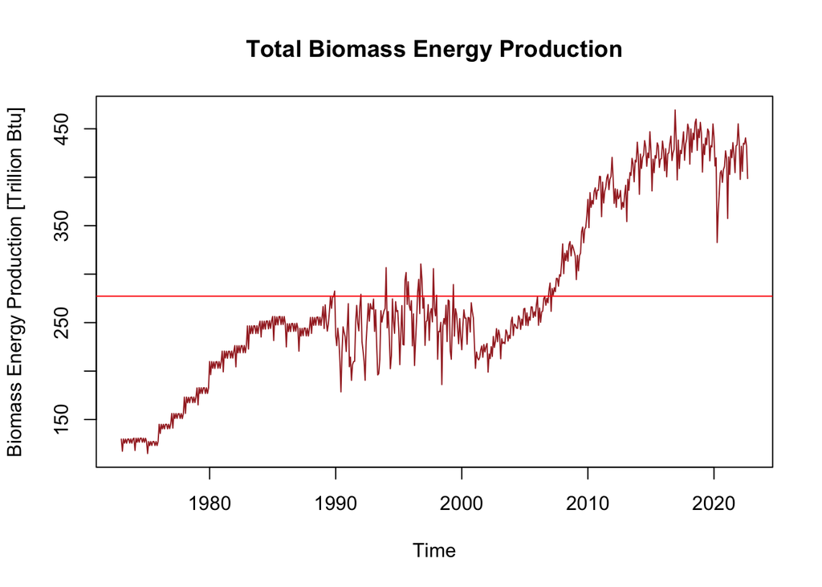

```r
# Time series plot for Total Biomass Energy Production
plot(ts_data[,"Total Biomass Energy Production"],type="l",col="brown",ylab="Biomass Energy Production [Trillion Btu]",main="Total Biomass Energy Production")
abline(h=mean(ts_data[,"Total Biomass Energy Production"]),col="red")
```

Overall, the total biomass energy production showed an upward trend during the past five decades. Before 1990, the total biomass energy production increased from ~130 to ~280 (mean of the series) trillion Btu with small fluctuations, followed by much greater fluctuations during 1990 - 2001 around 250 trillion Btu. This suggests that there might exist some resistance to the production of biomass energy during this decade. Afterwards, the total biomass energy production continued to rise to around 450 trillion Btu with increasing fluctuations and saw a sharp decline during 2019 - 2020 but resumed increasing thereafter.

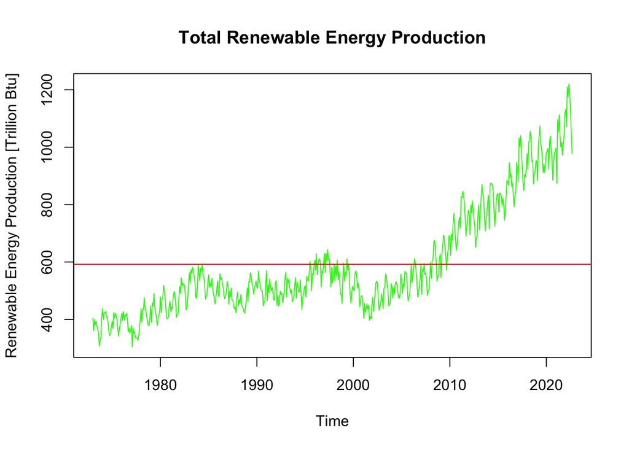

```r
# Time series plot for Total Renewable Energy Production
plot(ts_data[,"Total Renewable Energy Production"],type="l",col="green",ylab="Renewable Energy Production [Trillion Btu]",main="Total Renewable Energy Production")
abline(h=mean(ts_data[,"Total Renewable Energy Production"]),col="red")
```

Overall, the total renewable energy production showed an upward trend during the past five decades. Before 2000, the total renewable energy production fluctuated between ~ 300 and ~ 600 trillion Btu (mean of the series) with two peaks around 1984 and 1997. Afterwards, the total renewable energy production rose rapidly and significantly to 1200 trillion Btu with increasing fluctuations. This implies that there might be policy supporting the development of renewable energy after 2000.

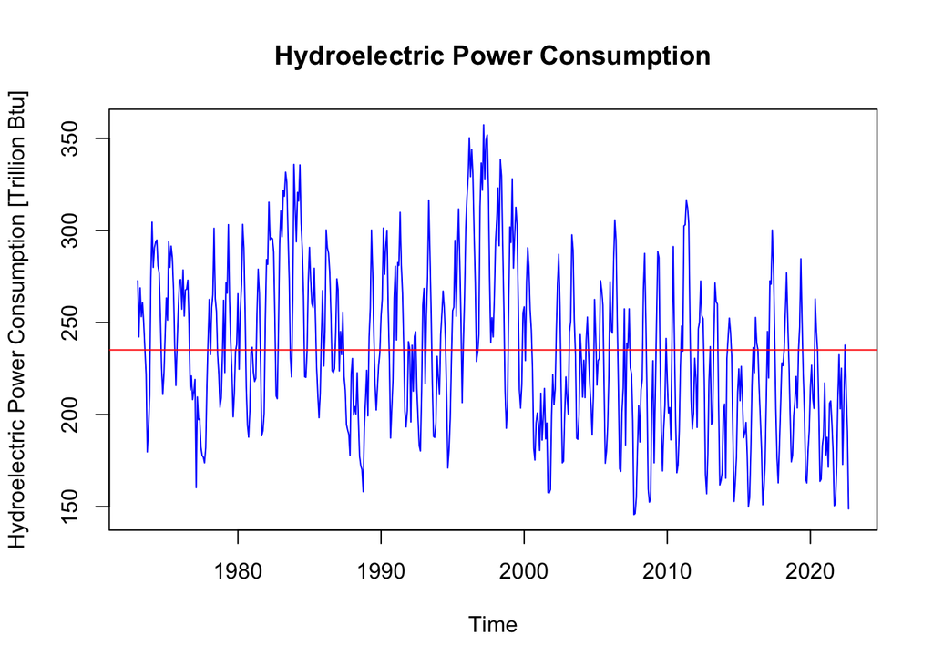

```r
# Time series plot for Hydroelectric Power Consumption
plot(ts_data[,"Hydroelectric Power Consumption"],type="l",col="blue",ylab="Hydroelectric Power Consumption [Trillion Btu]",main="Hydroelectric Power Consumption")
abline(h=mean(ts_data[,"Hydroelectric Power Consumption"]),col="red")
```

Overall, the hydroelectric power consumption showed a downward trend with constant fluactuations but stayed in a relatively narrow range (150 ~ 350 trillion Btu) around the mean (~235 trillion Btu) during the past five decades. This possibly implies a decreasing dependence on hydroelectric power.

## Question 5

Compute the correlation between these three series. Are they significantly correlated? Explain your answer.

Since not all variables are normal distribution, and not all pairs are linearly/ monotonically related, I used Kendall rank correlation.

```r
# Kendall rank correlation
cor1 <- cor.test(ts_data[,1],ts_data[,2], method = "kendall")
cor1
```

```
##
##  Kendall's rank correlation tau
##
## data:  ts_data[, 1] and ts_data[, 2]
## z = 26.114, p-value < 2.2e-16
## alternative hypothesis: true tau is not equal to 0
## sample estimates:
##       tau
## 0.7146061
```

```r
cor2 <- cor.test(ts_data[,1],ts_data[,3], method = "kendall")
cor2
```

```
##
##  Kendall's rank correlation tau
##
## data:  ts_data[, 1] and ts_data[, 3]
## z = -6.9662, p-value = 3.256e-12
## alternative hypothesis: true tau is not equal to 0
## sample estimates:
##        tau
## -0.1906298
```

```r
cor3 <- cor.test(ts_data[,2],ts_data[,3], method = "kendall")
cor3
```

```
##
##  Kendall's rank correlation tau
##
## data:  ts_data[, 2] and ts_data[, 3]
## z = 2.1568, p-value = 0.03102
## alternative hypothesis: true tau is not equal to 0
## sample estimates:
##        tau
## 0.05901993
```

The correlation coefficient between total biomass energy production and total renewable energy production is 0.71 (p -> 0). Therefore, the positive correlation between those two parameters is strong and significant.

The correlation coefficient between total biomass energy production and hydroelectric power consumption is -0.19 (p -> 0). Therefore, the negative correlation between those two parameters is relatively weak but significant.

The correlation coefficient between total renewable energy production and hydroelectric power consumption is 0.06 (p = 0.03). Therefore, the positive correlation between those two parameters is very weak but significant at a significance level of 0.05.

## Question 6

Compute the autocorrelation function from lag 1 up to lag 40 for these three variables. What can you say about these plots? Do the three of them have the same behavior?

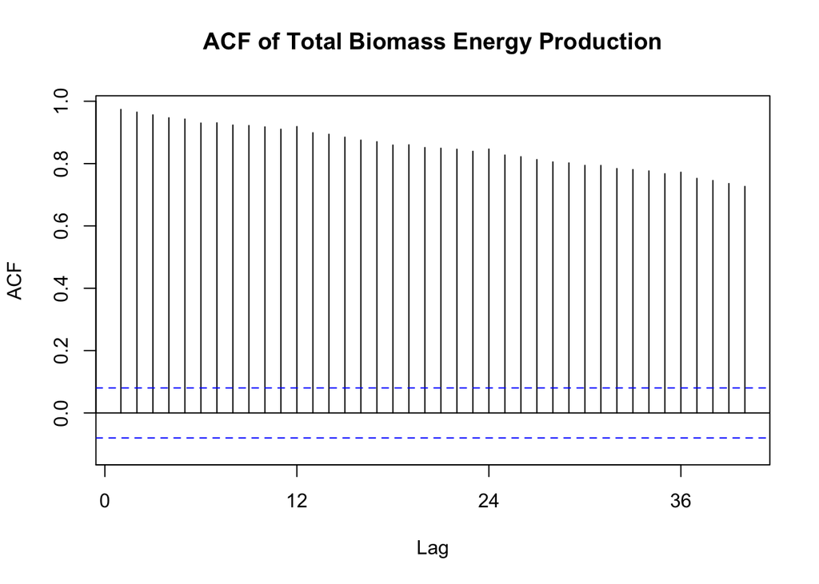

```r
#Total Biomass Energy Production
acf_bio <- Acf(ts_data[,1],type="correlation",lag.max = 40,
               main = "ACF of Total Biomass Energy Production")
```

```r
acf_bio
```

```
##
## Autocorrelations of series 'ts_data[, 1]', by lag
##
##     0     1     2     3     4     5     6     7     8     9    10    11    12
## 1.000 0.974 0.965 0.956 0.947 0.943 0.930 0.931 0.924 0.922 0.918 0.910 0.919
##    13    14    15    16    17    18    19    20    21    22    23    24    25
## 0.899 0.894 0.885 0.875 0.870 0.859 0.860 0.851 0.849 0.846 0.839 0.847 0.827
##    26    27    28    29    30    31    32    33    34    35    36    37    38
## 0.822 0.813 0.805 0.802 0.794 0.794 0.784 0.781 0.776 0.767 0.772 0.753 0.746
##    39    40
## 0.736 0.727
```

The ACF of time-series data of total biomass energy production shows very weak seasonality – 3 peaks can be observed at 12 lags, 24 lags, and 36 lags. Overall, the ACF decreases with increasing lag but stay large (0.727~0.974) over the 40 lags.

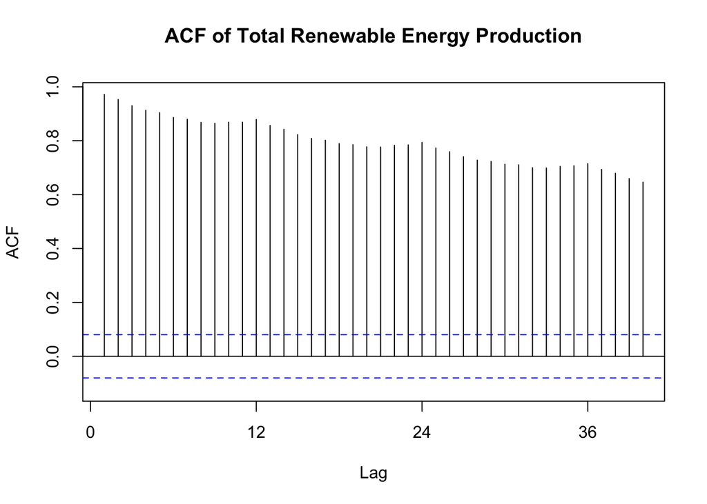

```r
# Total Renewable Energy Production
acf_ren <- Acf(ts_data[,2],type="correlation",lag.max = 40, main = "ACF of Total Renewable Energy Production")
```

```r
acf_ren
```

```
##
## Autocorrelations of series 'ts_data[, 2]', by lag
##
##     0     1     2     3     4     5     6     7     8     9    10    11    12
## 1.000 0.972 0.953 0.930 0.913 0.904 0.886 0.880 0.868 0.865 0.869 0.869 0.879
##    13    14    15    16    17    18    19    20    21    22    23    24    25
## 0.857 0.842 0.823 0.808 0.802 0.789 0.785 0.777 0.776 0.783 0.784 0.794 0.773
##    26    27    28    29    30    31    32    33    34    35    36    37    38
## 0.759 0.741 0.728 0.723 0.713 0.711 0.700 0.699 0.705 0.707 0.715 0.693 0.679
##    39    40
## 0.660 0.646
```

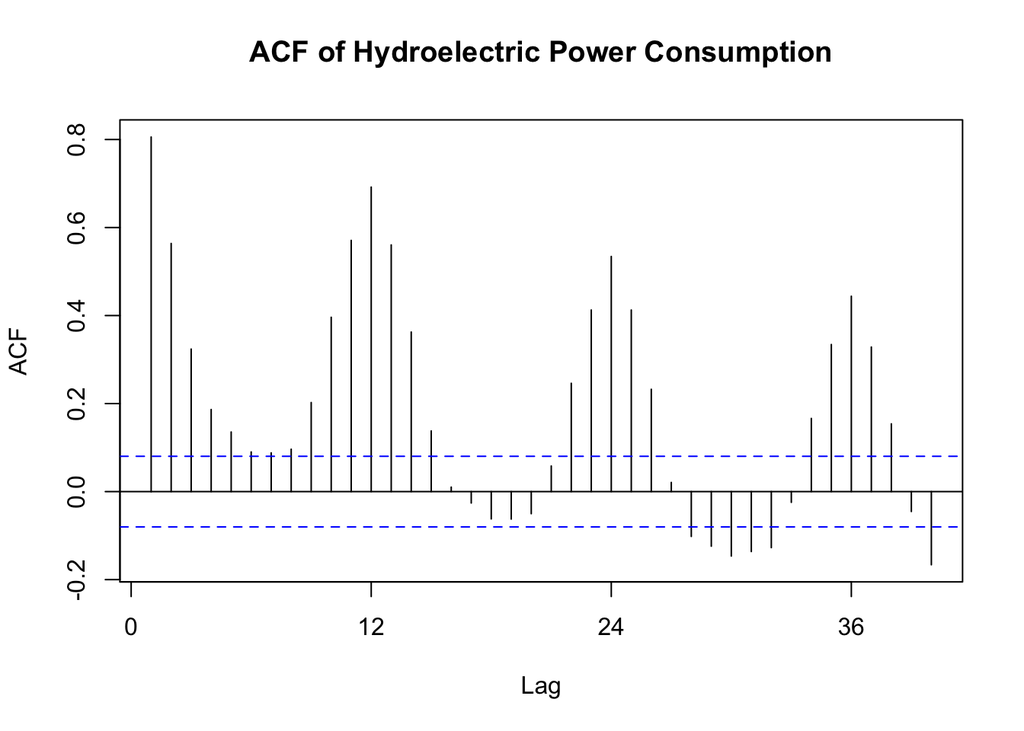

```r
# Hydroelectric Power Consumption
acf_hyd <- Acf(ts_data[,3],type="correlation",lag.max = 40, main = "ACF of Hydroelectric Power Consumption")
```

```r
acf_hyd
```

```
##
## Autocorrelations of series 'ts_data[, 3]', by lag
##
##      0      1      2      3      4      5      6      7      8      9     10
##  1.000  0.806  0.564  0.324  0.187  0.135  0.090  0.088  0.096  0.202  0.396
##     11     12     13     14     15     16     17     18     19     20     21
##  0.571  0.692  0.561  0.363  0.138  0.010 -0.026 -0.062 -0.062 -0.050  0.058
##     22     23     24     25     26     27     28     29     30     31     32
##  0.246  0.413  0.534  0.413  0.232  0.021 -0.102 -0.124 -0.146 -0.136 -0.127
##     33     34     35     36     37     38     39     40
## -0.024  0.166  0.334  0.444  0.328  0.154 -0.045 -0.166
```

The ACF of time-series data of Hydroelectric Power Consumption shows strong seasonality. 3 positive peaks can be observed at 12 lags, 24 lags, and 36 lags while 2 negative peaks can be observed at 18/19 lags and 30 lags. Over the first year, the ACF decreases over the first half of the year and increases over the second half of the year. However, starting from the second year, the ACF becomes negative roughly during the second and third quarter. Overall, the ACF values decrease with increasing lag over the 40 lags, the positive ACF gets weaker while the negative ACF gets stronger and more statistically significant.

## Question 7

Compute the partial autocorrelation function from lag 1 to lag 40 for these three variables. How these plots differ from the ones in Q6?

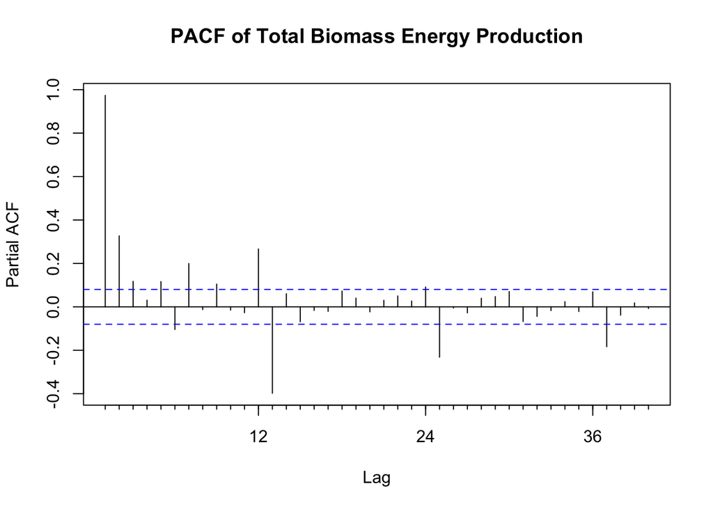

```r
#Total Biomass Energy Production
pacf_bio <-Pacf(ts_data[,1],lag.max = 40, main = "PACF of Total Biomass Energy Production")
```

```r
pacf_bio
```

```
##
## Partial autocorrelations of series 'ts_data[, 1]', by lag
##
##      1      2      3      4      5      6      7      8      9     10     11
##  0.974  0.327  0.117  0.031  0.116 -0.104  0.199 -0.013  0.105 -0.015 -0.027
##     12     13     14     15     16     17     18     19     20     21     22
##  0.266 -0.398  0.060 -0.069 -0.016 -0.021  0.073  0.040 -0.023  0.030  0.050
##     23     24     25     26     27     28     29     30     31     32     33
##  0.027  0.091 -0.232 -0.006 -0.028  0.039  0.047  0.071 -0.068 -0.044 -0.017
##     34     35     36     37     38     39     40
##  0.024 -0.022  0.069 -0.183 -0.039  0.018 -0.008
```

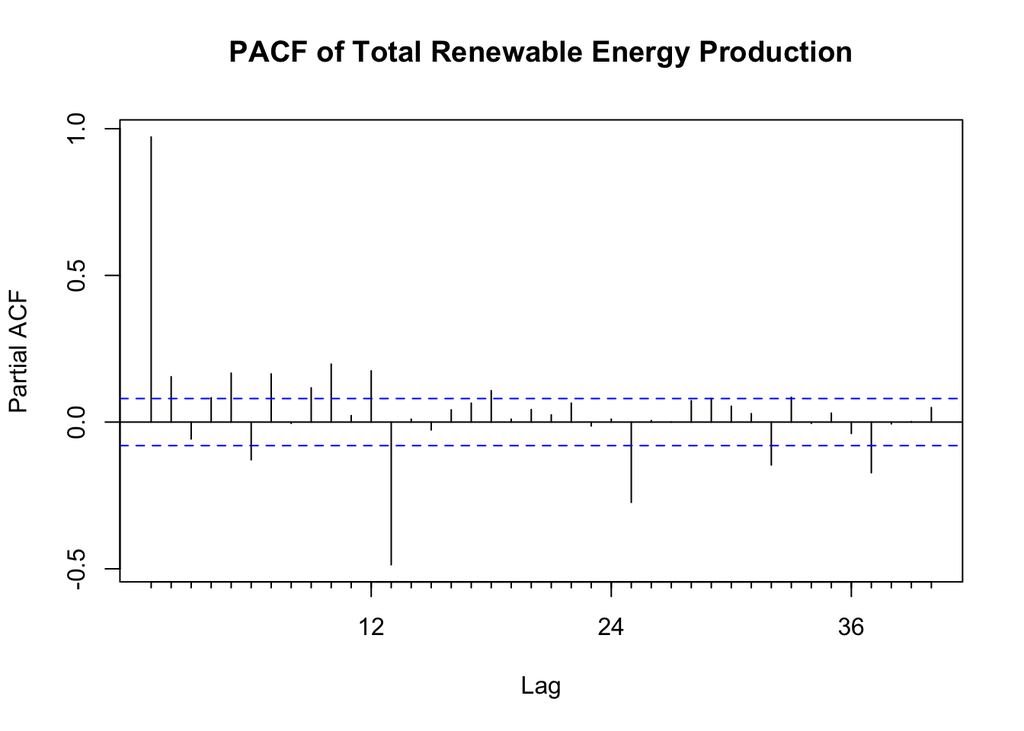

```r
# Total Renewable Energy Production
pacf_ren <- Pacf(ts_data[,2],lag.max = 40, main = "PACF of Total Renewable Energy Production")
```

```r
pacf_ren
```

```
##
## Partial autocorrelations of series 'ts_data[, 2]', by lag
##
##      1      2      3      4      5      6      7      8      9     10     11
##  0.972  0.155 -0.058  0.083  0.167 -0.129  0.164 -0.004  0.117  0.198  0.022
##     12     13     14     15     16     17     18     19     20     21     22
##  0.175 -0.486  0.010 -0.027  0.042  0.065  0.107  0.010  0.043  0.025  0.065
##     23     24     25     26     27     28     29     30     31     32     33
## -0.013  0.010 -0.274  0.005  0.000  0.073  0.080  0.054  0.029 -0.146  0.085
##     34     35     36     37     38     39     40
## -0.004  0.031 -0.039 -0.173 -0.006  0.002  0.050
```

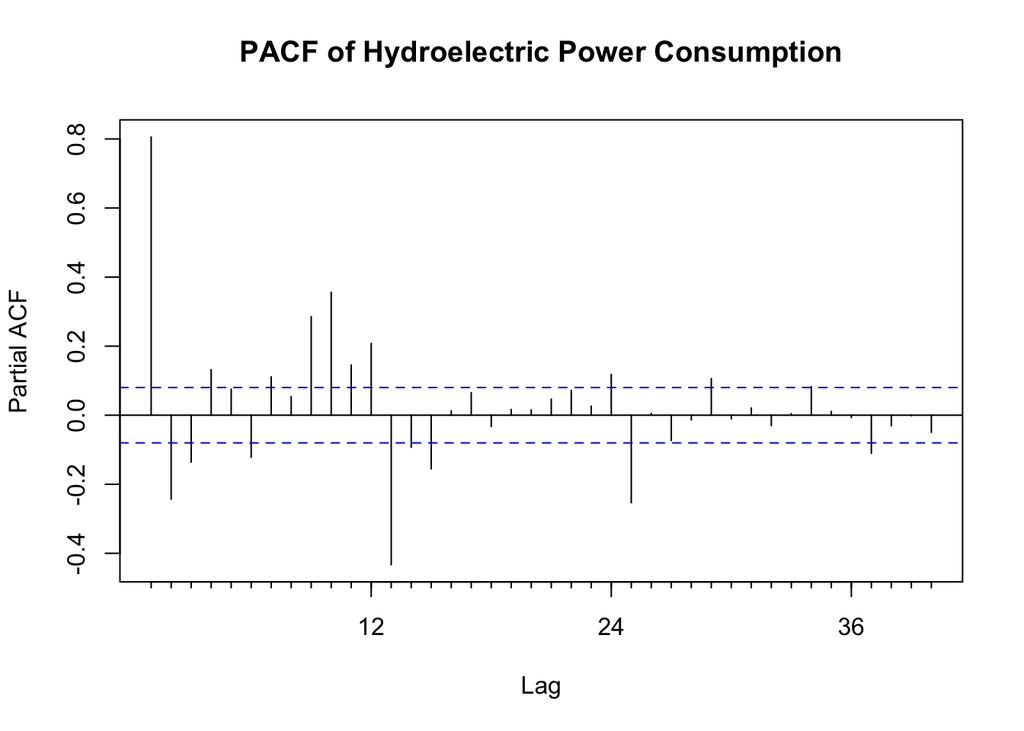

```r
# Hydroelectric Power Consumption
pacf_hyd <- Pacf(ts_data[,3],lag.max = 40, main = "PACF of Hydroelectric Power Consumption")
```

```r
pacf_hyd
```

```
##
## Partial autocorrelations of series 'ts_data[, 3]', by lag
##
##      1      2      3      4      5      6      7      8      9     10     11
##  0.806 -0.243 -0.136  0.132  0.075 -0.122  0.111  0.054  0.285  0.356  0.145
##     12     13     14     15     16     17     18     19     20     21     22
##  0.208 -0.433 -0.093 -0.156  0.013  0.065 -0.033  0.017  0.015  0.047  0.072
##     23     24     25     26     27     28     29     30     31     32     33
##  0.026  0.118 -0.253  0.005 -0.073 -0.014  0.106 -0.011  0.021 -0.030  0.004
##     34     35     36     37     38     39     40
##  0.083  0.011 -0.007 -0.111 -0.031 -0.002 -0.050
```